[O’Hara on GitHub](https://github.com/oharac)

# Compare cumulative impacts per species to IUCN status

Compiled on Wed Feb 23 09:24:34 2022 by ohara

```r
knitr::opts_chunk$set(echo = TRUE, message = FALSE, warning = FALSE)

library(raster)
library(tidyverse)
library(here)
library(RColorBrewer)
library(oharac)
library(caret)
source(here('common_fxns.R'))
```

# 1 Summary

Calculate the cumulative impact across each species range (total and coastal-only). Relative CHI will be the total CHI (summed across all cells and all stressors) normalized by the total range (total and coastal-only). The relative CHI is effectively the average CHI per km<sup>2</sup> across the species’ range.

Perform a regression of IUCN extinction risk classification as a function of relative overall CHI and overall range, and then do the same for coastal.

# 2 Data

- Species impact scores from script 5
- IUCN extinction risk scores from IUCN

# 3 Methods

## 3.1 Read in species impacts for those spp assessed by IUCN; summarize to CHI

Summarize to cumulative impacts by entire range and by coastal range.

Each file has a row for each stressor-vulnerability match; columns are:

- `str_vuln` (chr): name of stressor/vuln combo, as -
- `impact_tot` (dbl): sum across all cells of stressor intensity $\times$ vulnerability $\times$ ocean area
- `impact_coastal` (dbl): sum across all coastal cells (≤200m) of stressor intensity $\times$ vulnerability $\times$ ocean area
- `range_tot_km2` (dbl): sum of ocean area of all cells across entire range
- `range_coastal_km2` (dbl): sum of ocean area of all cells across coastal range

```r
spp_chi_file <- here_anx('int/spp_chi_summary.csv')

if(!file.exists(spp_chi_file)) {
  spp_imp_fs <- list.files(here_anx('impacts_by_species'),
                           pattern = '^impacts_.+.csv', full.names = TRUE)

  spp_imp_raw_df <- parallel::mclapply(spp_imp_fs, mc.cores = 40,
                                       read_csv, show_col_types = FALSE) %>%
    setNames(basename(spp_imp_fs)) %>%
    bind_rows(.id = 'f')

  spp_ranges <- spp_imp_raw_df %>%
    select(f, range_km2, range) %>%
    distinct() %>%
    spread(range, range_km2) %>%
    rename(range_cst_km2 = coastal, range_tot_km2 = full)

  spp_impacts_df <- spp_imp_raw_df %>%
    select(f, vuln, stressor, impact_tot, range) %>%
    spread(range, impact_tot) %>%
    rename(impact_tot = full, impact_cst = coastal)

  spp_cv_df <- spp_imp_raw_df %>%
    select(f, vuln, stressor, impact_cv, range) %>%
    spread(range, impact_cv) %>%
    rename(impact_cv_tot = full, impact_cv_cst = coastal)

  spp_impacts_npp_df <- spp_imp_raw_df %>%
    select(f, vuln, stressor, impact_npp_tot, range) %>%
    spread(range, impact_npp_tot) %>%
    rename(impact_npp_tot = full, impact_npp_cst = coastal)

  spp_npp_cv_df <- spp_imp_raw_df %>%
    select(f, vuln, stressor, impact_npp_cv, range) %>%
    spread(range, impact_npp_cv) %>%
    rename(impact_npp_cv_tot = full, impact_npp_cv_cst = coastal)

  iucn_worms_lookup <- read_csv(here('_data/iucn_spp', 'iucn_to_worms_match.csv'))

  spp_imp_cv_df <- full_join(spp_impacts_df, spp_cv_df,
                             by = c('f', 'vuln', 'stressor')) %>%
    full_join(spp_impacts_npp_df, by = c('f', 'vuln', 'stressor')) %>%
    full_join(spp_npp_cv_df, by = c('f', 'vuln', 'stressor')) %>%
    left_join(spp_ranges, by = 'f') %>%
    ### extract species and map info from filename
    mutate(map_src = str_extract(f, '_iucn_|_am_') %>% str_remove_all('_'),
           iucn_sid = str_extract(f, '[0-9]+') %>% as.integer(),
           spp_from_f = str_remove_all(f, 'impacts_(am|iucn)_|.csv')) %>%
    left_join(iucn_worms_lookup, by = 'iucn_sid') %>%
    mutate(sciname = ifelse(is.na(worms_name),
                            str_replace_all(spp_from_f, '_', ' '),
                            worms_name)) %>%
    select(sciname, iucn_sid, map_src, vuln, stressor,
           impact_cst, impact_tot, impact_cv_cst, impact_cv_tot,
           impact_npp_cst, impact_npp_tot, impact_npp_cv_cst, impact_npp_cv_tot,
           range_cst_km2, range_tot_km2) %>%
    distinct() %>%
    filter(range_tot_km2 > 0 & !is.na(impact_tot))

  write_csv(spp_imp_cv_df, spp_chi_file)
}
```

### 3.1.1 Assemble IUCN Red List categories for species in IUCN maps and AquaMaps maps

```r
iucn_worms_lookup <- read_csv(here('_data/iucn_spp', 'iucn_to_worms_match.csv'),
                              show_col_types = FALSE)

iucn_assessed <- read_csv(here('_data/iucn_spp/iucn_marine_spp_info_2021-3.csv'),
                              show_col_types = FALSE) %>%
  select(iucn_sid, cat, cat_score) %>%
  left_join(iucn_worms_lookup, by = 'iucn_sid') %>%
  mutate(threatened = case_when(cat == 'dd' ~ NA,
                                cat %in% c('lc', 'nt') ~ FALSE,
                                TRUE ~ TRUE),
         atrisk     = case_when(cat == 'dd' ~ NA,
                                cat %in% c('lc') ~ FALSE,
                                TRUE ~ TRUE)) %>%
  select(iucn_sid, iucn_sciname = sciname, sciname = worms_name, cat, cat_score, threatened, atrisk)
iucn_mapped <- read_csv(here('_data/iucn_spp/spp_marine_maps_2021-3.csv'),
                              show_col_types = FALSE)

assessed_in_am <- get_am_spp_info() %>%
  select(am_sid, am_sciname, sciname, iucn_sid) %>%
  inner_join(iucn_assessed %>%
               select(iucn_sid, cat, threatened, atrisk) %>% distinct(),
             by = 'iucn_sid') %>%
  select(sciname, cat, threatened, atrisk) %>%
  distinct() %>%
  mutate(map_src = 'am',
         iucn_sid = -1)

assessed_in_iucn_maps <- iucn_assessed %>%
  filter(iucn_sid %in% iucn_mapped$iucn_sid) %>%
  select(sciname, iucn_sid, cat, threatened, atrisk) %>%
  distinct() %>%
  mutate(map_src = 'iucn')

assessed_df <- bind_rows(assessed_in_am, assessed_in_iucn_maps)
```

### 3.1.2 Combine IUCN categories with impacts

```r
iucn_impacts_df <- read_csv(spp_chi_file,
                            show_col_types = FALSE) %>%
  mutate(iucn_sid = ifelse(is.na(iucn_sid), -1, iucn_sid)) %>%
  inner_join(assessed_df, by = c('sciname', 'iucn_sid', 'map_src')) %>%
  mutate(iucn_fct = toupper(cat),
         iucn_fct = factor(iucn_fct, levels = c('LC', 'NT', 'VU', 'EN', 'CR', 'EX', 'DD')))

check_df <- iucn_impacts_df %>%
  select(sciname, iucn_sid, map_src) %>%
  distinct() %>%
  group_by(sciname) %>%
  summarize(n = n(),
            map_src = paste(map_src, collapse = ';'))


spp_chi_iucn_clean <- iucn_impacts_df %>%
  filter(stressor == 'cumulative') %>%
  mutate(chi_rel_tot = impact_tot / range_tot_km2,
         chi_rel_cst = impact_cst / range_cst_km2,
         chi_npp_tot = impact_npp_tot / range_tot_km2,
         chi_npp_cst = impact_npp_cst / range_cst_km2) %>%
  filter(!is.na(threatened))
```

## 3.2 Try some simple tests

### 3.2.1 examine CHI by range

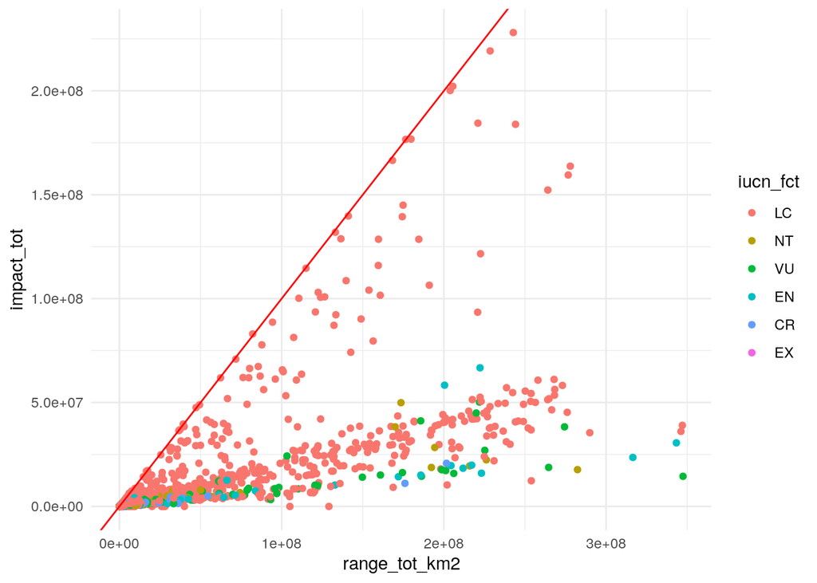

```r
ggplot(spp_chi_iucn_clean, aes(x = range_tot_km2, y = impact_tot)) +
  geom_point(aes(color = iucn_fct)) +
  geom_abline(slope = 1, intercept = 0, color = 'red', size = .5) +
  # scale_y_log10() +
  theme_minimal()
```

Technically possible for species to have higher total impacts than range, e.g., if high vulnerability (near 1) to multiple very intense stressor (near 1) across most of its range.

Questions:

- Are the spp near the 1:1 line due to cumulative effects, or dominated by a single stressor?
- there seem to be a few “clusters” of slopes…

## 3.3 Binomial logistic regression

### 3.3.1 Prob of threatened = TRUE as function of CHI and range

```r
taxa_df <- assemble_worms() %>%
  mutate(taxon = ifelse(phylum == 'chordata' | class == 'cephalopoda', class, phylum)) %>%
  select(species, taxon, phylum, class)

chi_threatened_valid <- spp_chi_iucn_clean %>%
  left_join(taxa_df, by = c('sciname' = 'species')) %>%
  filter(!is.na(threatened)) %>%
  mutate(inv_log_r_tot  = 1/log(range_tot_km2),
         inv_log_r_cst  = 1/log(range_cst_km2),
         inv_sqrt_r_tot = 1/sqrt(range_tot_km2),
         inv_sqrt_r_cst = 1/sqrt(range_cst_km2)) %>%
  mutate(qtile_r = ntile(range_tot_km2, n = 4))
```

```r
taxa <- chi_threatened_valid$taxon %>% unique() %>% sort()

results <- data.frame()

frms <- c(atrisk ~ chi_npp_tot + impact_npp_cv_tot + inv_log_r_tot,
          atrisk ~ chi_npp_cst + impact_npp_cv_cst + inv_log_r_cst,
          atrisk ~ chi_rel_tot + impact_cv_tot + inv_log_r_tot,
          atrisk ~ chi_rel_tot + impact_cv_tot + inv_log_r_tot,
          atrisk ~ chi_rel_tot + inv_log_r_tot,
          atrisk ~ chi_rel_tot + impact_cv_tot,
          atrisk ~ chi_rel_tot,
          atrisk ~ chi_rel_cst + impact_cv_cst + inv_log_r_cst,
          atrisk ~ chi_rel_cst + inv_log_r_cst,
          atrisk ~ chi_rel_cst + impact_cv_cst,
          atrisk ~ chi_rel_cst)

for(t in taxa) { ### t <- taxa[8]
  chi_tx_df <- chi_threatened_valid %>%
    filter(taxon == t) # %>% filter(cat != 'lc')

  blr_list <- lapply(frms,
                     FUN = function(f) {
                       mdl <- glm(f,
                                  data = chi_tx_df,
                                  family = 'binomial') %>%
                         broom::tidy() %>% mutate(formula = deparse(f))
                     })

  df <- bind_rows(blr_list) %>%
    mutate(taxon = t)

  results <- bind_rows(results, df)
}


x <- results %>%
  filter(term != '(Intercept)')


mdl <- glm(atrisk ~ chi_npp_cst + impact_npp_cv_cst + inv_log_r_cst,
           data = chi_threatened_valid %>% filter(taxon == 'reptilia'),
           family = 'binomial')
summary(mdl)
```

```
##
## Call:
## glm(formula = atrisk ~ chi_npp_cst + impact_npp_cv_cst + inv_log_r_cst,
##     family = "binomial", data = chi_threatened_valid %>% filter(taxon ==
##         "reptilia"))
##
## Deviance Residuals:
##     Min       1Q   Median       3Q      Max
## -2.2635  -0.7474  -0.4755   1.0481   1.9600
##
## Coefficients:
##                   Estimate Std. Error z value Pr(>|z|)
## (Intercept)       -11.6899     3.3765  -3.462 0.000536 ***
## chi_npp_cst         5.6755     2.2474   2.525 0.011556 *
## impact_npp_cv_cst   2.0221     0.6739   3.001 0.002694 **
## inv_log_r_cst      41.2697    19.1039   2.160 0.030751 *
## ---
## Signif. codes:  0 '***' 0.001 '**' 0.01 '*' 0.05 '.' 0.1 ' ' 1
##
## (Dispersion parameter for binomial family taken to be 1)
##
##     Null deviance: 93.828  on 72  degrees of freedom
## Residual deviance: 76.426  on 69  degrees of freedom
## AIC: 84.426
##
## Number of Fisher Scoring iterations: 4
```

### 3.3.2 Try PCA on indiv stressors then BLR

PCA can eliminate multicollinearity among variables.

```r
spread_stressors <- function(df) {
  pca_ready_df <- df %>%
    select(sciname, iucn_sid, stressor, imp_rel_tot, threatened, inv_log_r_tot) %>%
    group_by(stressor) %>%
    ### identify and drop any all-zero-stressor
    filter(!all(imp_rel_tot == 0)) %>%
    ungroup() %>%
    spread(stressor, imp_rel_tot) %>%
    mutate(across(where(is.numeric), .fns = ~ ifelse(is.na(.x), 0, .x)))
  return(pca_ready_df)
}

prep_for_glm <- function(df, pca_thresh = 0.95) {
  pca_out <- df %>%
    select(-sciname, -iucn_sid, -threatened, -inv_log_r_tot) %>%
    # scale() %>% ### values already between 0-1; scale may lose vulnerability magnitude
    prcomp()
  ### summary(pca_out)

  ### Identify the PC number where the threshold is first met
  cum_var <- ((pca_out$sdev)^2 / sum((pca_out$sdev)^2)) %>% cumsum()
  n_pcs <- which(cum_var > pca_thresh)[1]
  message('Threshold of ', pca_thresh, ' results in ', n_pcs, ' principal components...')

  pca_results_df <- data.frame(df %>%
                                 select(threatened, inv_log_r_tot),
                               pca_out$x[ , 1:n_pcs]) %>%
    mutate(threatened = factor(threatened))
  return(pca_results_df)
}
```

#### 3.3.2.1 model accuracy by taxon

```r
spp_impacts_iucn_clean <- iucn_impacts_df %>%
  filter(stressor != 'cumulative') %>%
  mutate(imp_rel_tot = impact_tot / range_tot_km2,
         imp_rel_cst = impact_cst / range_cst_km2) %>%
  filter(!is.na(threatened))

impacts_threatened_valid <- spp_impacts_iucn_clean %>%
  left_join(taxa_df, by = c('sciname' = 'species')) %>%
  filter(!is.na(threatened)) %>%
  mutate(inv_log_r_tot  = 1/log(range_tot_km2),
         inv_log_r_cst  = 1/log(range_cst_km2)) %>%
  select(sciname, iucn_sid, vuln, stressor, threatened, imp_rel_tot, taxon, inv_log_r_tot) %>%
  distinct()

taxa <- impacts_threatened_valid$taxon %>% unique() %>% sort()

results_df <- data.frame()

for(t in taxa) { ### t <- taxa[8]
  message('Processing ', t, '...')
  imp_tx_df <- impacts_threatened_valid %>%
    filter(taxon == t) # %>% filter(cat != 'lc')

  pct_thr <- sum(imp_tx_df$threatened) / nrow(imp_tx_df)
  zero_rule <- max(pct_thr, 1 - pct_thr)

  ###
  imp_tx_info <- spread_stressors(imp_tx_df)

  imp_tx_pca_df <- prep_for_glm(imp_tx_info)

  tr_ctrl <- trainControl(method = 'repeatedcv', number = 10, repeats = 10)
  ### train the model
  mdl1 <- train(threatened ~ .,
                data = imp_tx_pca_df,
                method = 'glm', family = 'binomial',
                trControl = tr_ctrl)
  tx_results_df <- data.frame(taxon = t,
                              n_spp = nrow(imp_tx_df),
                              pct_thr = pct_thr,
                              n_pcs = ncol(imp_tx_pca_df) - 2,
                              accuracy = mdl1$results$Accuracy,
                              kappa    = mdl1$results$Kappa,
                              zero_rl  = zero_rule) %>%
    mutate(kappa_0 = (accuracy - zero_rl) / (1 - zero_rl))

  results_df <- bind_rows(results_df, tx_results_df)
}

knitr::kable(results_df %>% arrange(-kappa_0), digits = 4)
```

| taxon | n_spp | pct_thr | n_pcs | accuracy | kappa | zero_rl | kappa_0 |
| --- | --- | --- | --- | --- | --- | --- | --- |
| mammalia | 2055 | 0.3869 | 5 | 0.7674 | 0.4883 | 0.6131 | 0.3987 |
| cnidaria | 10449 | 0.3298 | 4 | 0.7260 | 0.2908 | 0.6702 | 0.1691 |
| myxini | 690 | 0.1957 | 4 | 0.8285 | 0.2854 | 0.8043 | 0.1234 |
| reptilia | 1108 | 0.2690 | 6 | 0.7630 | 0.3537 | 0.7310 | 0.1189 |
| aves | 4659 | 0.2898 | 4 | 0.7318 | 0.2031 | 0.7102 | 0.0745 |
| arthropoda | 2460 | 0.0122 | 1 | 0.9883 | 0.0000 | 0.9878 | 0.0407 |
| elasmobranchii | 14790 | 0.3864 | 1 | 0.6250 | 0.0550 | 0.6136 | 0.0296 |
| echinodermata | 1245 | 0.1566 | 2 | 0.8447 | -0.0017 | 0.8434 | 0.0086 |
| actinopterygii | 97751 | 0.0354 | 4 | 0.9648 | 0.1020 | 0.9646 | 0.0083 |
| mollusca | 9330 | 0.1158 | 4 | 0.8759 | 0.0612 | 0.8842 | -0.0720 |
| cephalopoda | 3195 | 0.0188 | 4 | 0.9681 | -0.0048 | 0.9812 | -0.7001 |

#### 3.3.2.2 across all spp simultaneously

```r
pct_thr <- sum(impacts_threatened_valid$threatened) / nrow(impacts_threatened_valid)
zero_rule <- max(pct_thr, 1 - pct_thr)

###
imp_all_info <- spread_stressors(impacts_threatened_valid)

imp_all_pca_df <- prep_for_glm(imp_all_info)

tr_ctrl <- trainControl(method = 'repeatedcv', number = 10, repeats = 10)
### train the model
mdl2 <- train(threatened ~ .,
              data = imp_all_pca_df,
              method = 'glm', family = 'binomial',
              trControl = tr_ctrl)
all_results_df <- data.frame(taxon = 'all taxa',
                            pct_thr = pct_thr,
                            n_pcs = ncol(imp_tx_pca_df) - 2,
                            accuracy = mdl2$results$Accuracy,
                            kappa    = mdl2$results$Kappa,
                            zero_rl  = zero_rule) %>%
  mutate(kappa_0 = (accuracy - zero_rl) / (1 - zero_rl))

knitr::kable(all_results_df, digits = 4)
```

| taxon | pct_thr | n_pcs | accuracy | kappa | zero_rl | kappa_0 |
| --- | --- | --- | --- | --- | --- | --- |
| all taxa | 0.1121 | 6 | 0.887 | 0.0351 | 0.8879 | -0.0077 |